# lab4

Yuchen Song_201830360498 - Xuewen Wang_201830120252

2021/9/29

### Data Loading and Pre-processing

```r
load(url("http://www.openintro.org/stat/data/bdims.RData"))
mdims = subset(bdims, sex == 1)
fdims = subset(bdims, sex == 0)
```

### Ex1

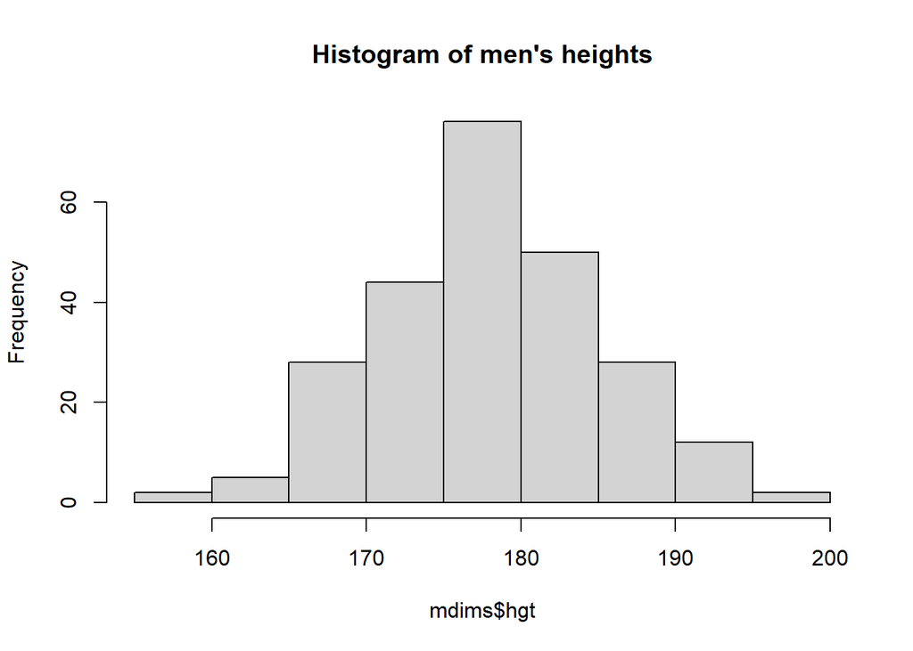

```r
hist(mdims$hgt,main = "Histogram of men's heights")
```

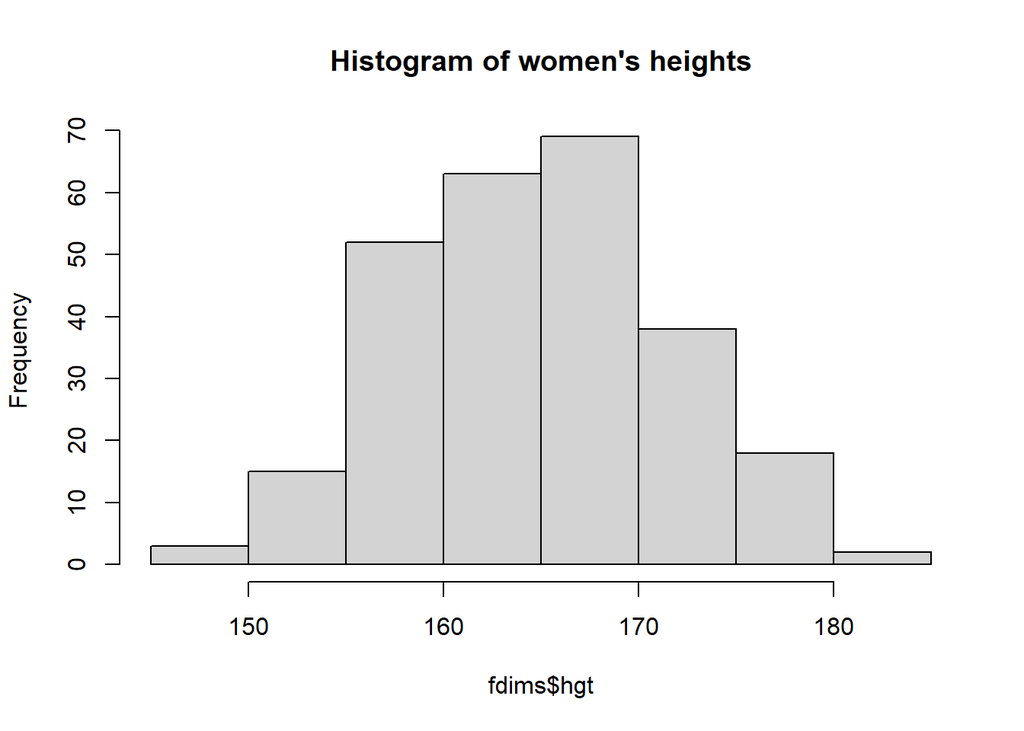

```r
hist(fdims$hgt,main = "Histogram of women's heights")
```

We can compare them from the aspects of symmetric, peak, the overall spread and other statistical magnitudes like std, mean, median, etc.

### Ex2

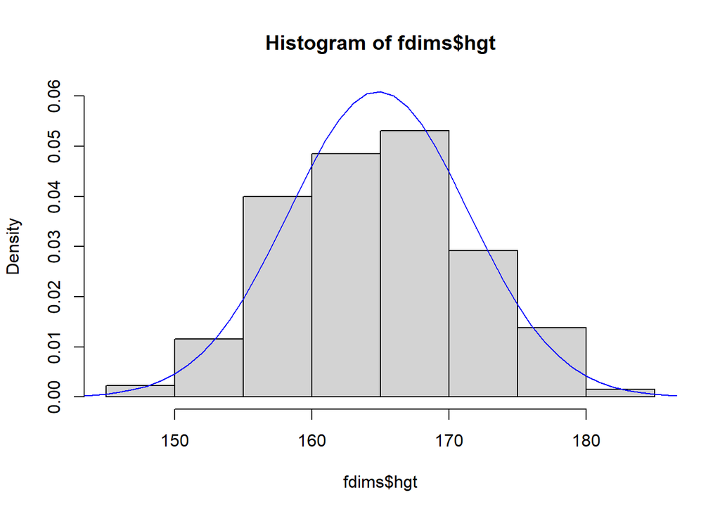

Yes, based on the plot, we can say that the data follow a nearly normal distribution.

### Ex3

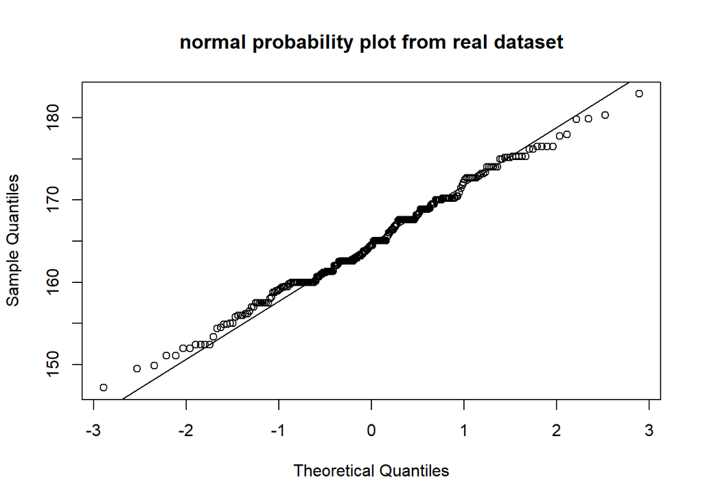

```r
set.seed(1116)
qqnorm(fdims$hgt,main = "normal probability plot from real dataset")
qqline(fdims$hgt)
```

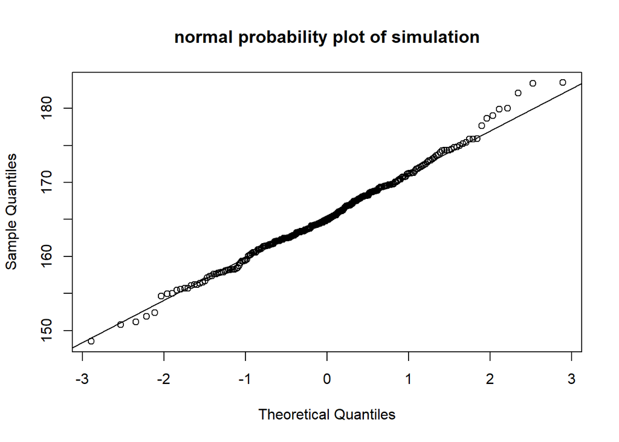

```r
sim_norm = rnorm(n = length(fdims$hgt), mean = fhgtmean, sd = fhgtsd)
qqnorm(sim_norm,main = "normal probability plot of simulation")
qqline(sim_norm)
```

Basically, most of the points fall on the line, but a few of them is actually not on the line, especially some points towards the tails.  
The overall pattern of the simulated plot is similar to real data plot, however, the middle part of the simulated plot fluctuates less and fit with the line better.

### Ex4

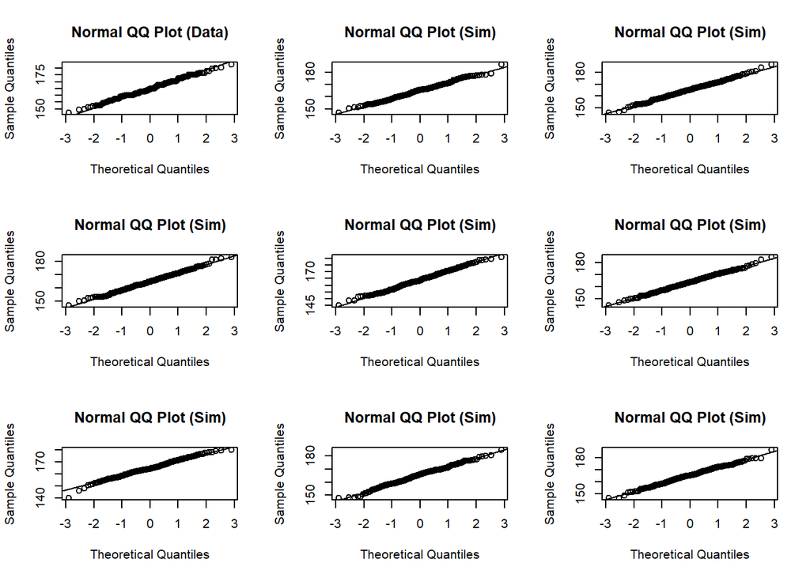

```r
set.seed(1121)
qqnormsim(fdims$hgt)
```

Compared with the normal probability plots created for simulated data, the plot of the real data shows a similar distribution, so it has some evidence to show that the female heights are nearly normal.

### Ex5

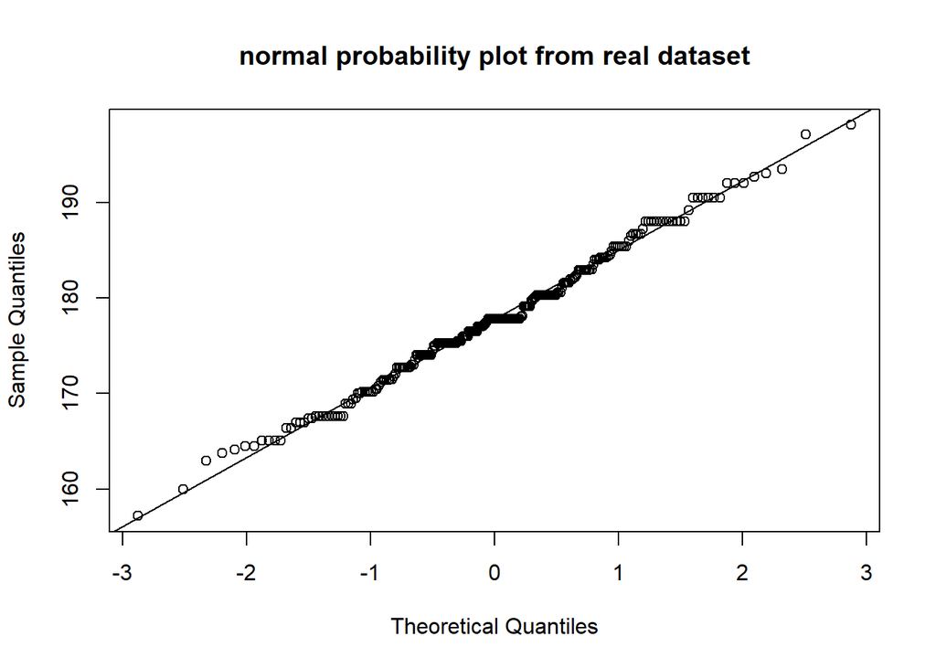

```r
set.seed(1127)
qqnorm(mdims$hgt,main = "normal probability plot from real dataset")
qqline(mdims$hgt)
```

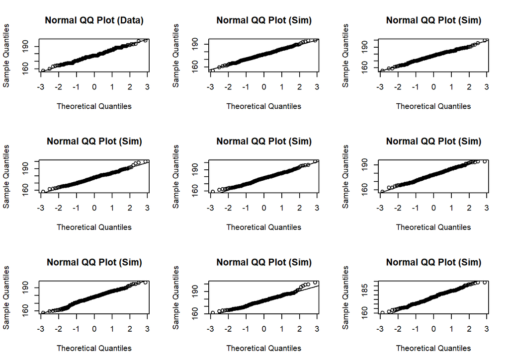

```r
qqnormsim(mdims$hgt)
```

### Ex6

```r
fwgtmean = mean(fdims$wgt)
fwgtsd   = sd(fdims$wgt)
wgt_prob_theo <- 1 - pnorm(q = 72, mean = fwgtmean, sd = fwgtsd)
wgt_prob_empir <- sum(fdims$wgt > 72) / length(fdims$wgt)
sprintf("The probability that the observed female weight value is more than 72 is %f and %f, from theoretical and empirical respectively. The difference between theoratical and empirical is %f",wgt_prob_theo,wgt_prob_empir,wgt_prob_theo-wgt_prob_empir)
```

```
## [1] "The probability that the observed female weight value is more than 72 is 0.117906 and 0.123077, from theoretical and empirical respectively. The difference between theoratical and empirical is -0.005171"
```

### Ex7

```r
hgt_prob_theo <- 1 - pnorm(q = 182, mean = fhgtmean, sd = fhgtsd)
hgt_prob_empir <- sum(fdims$hgt > 182) / length(fdims$hgt)
sprintf("The probability that the observed female height value is more than 182 is %f and %f, from theoretical and empirical respectively. The difference between theoratical and empirical is %f",hgt_prob_theo,hgt_prob_empir,hgt_prob_theo-hgt_prob_empir)
```

```
## [1] "The probability that the observed female height value is more than 182 is 0.004434 and 0.003846, from theoretical and empirical respectively. The difference between theoratical and empirical is 0.000588"
```

From the calculation above, we can find that the height variable has a closer agreement between the two methods.

### Ex8

1. 2
2. 3
3. 4
4. 1

### Ex9

```r
table(fdims$age)
```

```
##
## 18 19 20 21 22 23 24 25 26 27 28 29 30 31 32 33 34 35 36 37 38 39 40 41 42 43
##  3 20 25 12 13 19 13 19 12  8  9  9  5  4 16  5  7  4  6  7  4  3  8  7  2  1
## 44 45 46 47 48 49 52 53 56 64 67
##  4  4  2  1  1  1  2  1  1  1  1
```

Because there are many repeated values.

### Ex10

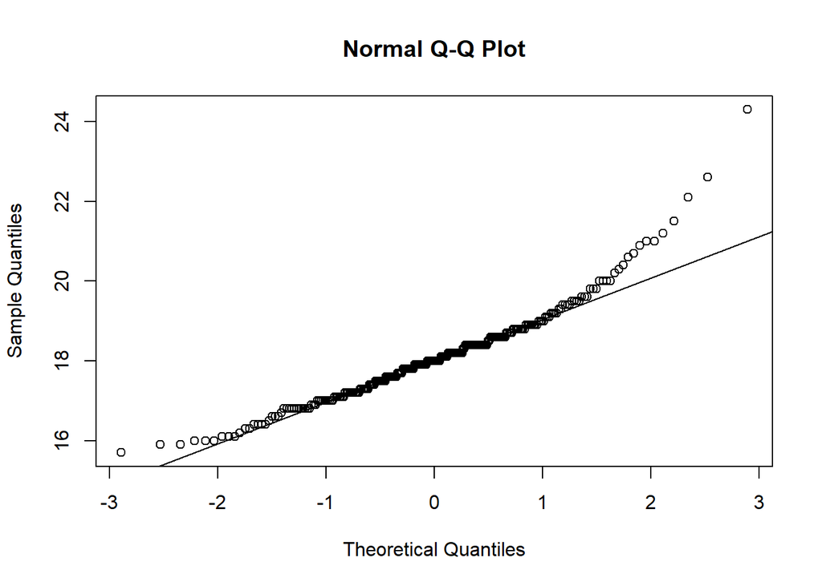

```r
qqnorm(fdims$kne.di)
qqline(fdims$kne.di)
```

Based on this normal probability plot, this variable is right skewed.

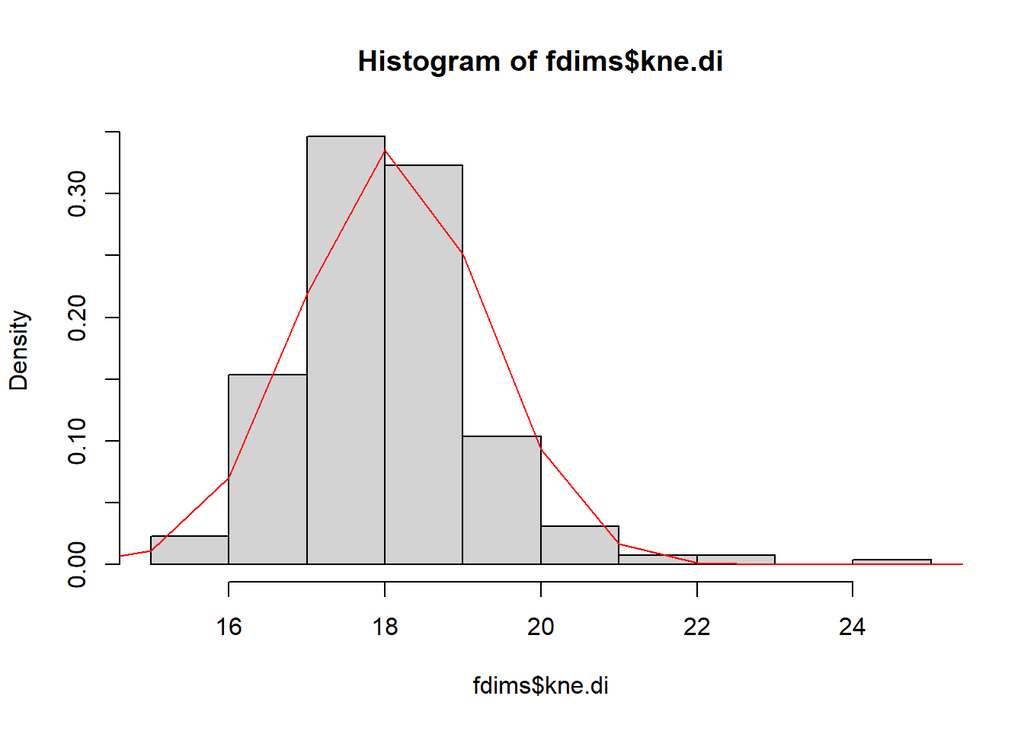

From the histogram, it is confirmed.